# Analisis de Qualys KDB

Juan José Vaquero García

2023-03-18

# Qualys KDB

Usaremos la base de datos de vulnerabilidades de Quadys para hacer un análisis de las vulnerabilidades teniendo en cuenta el número de CVEs y Bug Traqs definidos para cada una.

## Consideraciones previas

```
import xml.etree.ElementTree as ET

# Archivo XML de entrada
input_file = "/home/ubuntu/work/dds/repositories/DDSlab/data/qualys/latest.qkdb.xml"

# Archivo XML de salida
output_file = "/home/ubuntu/work/dds/repositories/DDSlab/data/qualys/latest.qkdb_out.xml"


# Parsear el archivo de entrada como un árbol de elementos
tree = ET.parse(input_file)
root = tree.getroot()

# Buscar todos los elementos VULN en el árbol
vuln_elems = root.findall(".//VULN")

# Iterar sobre cada elemento VULN y agregar el elemento CVE_LIST
for vuln_elem in vuln_elems:

    # Si el elemento CVE_LIST no existe, agregarlo
    if vuln_elem.find("CVE_LIST") is None:
        cve_list_elem = ET.SubElement(vuln_elem, "CVE_LIST")
        cve_elem = ET.SubElement(cve_list_elem, "CVE")
        id_elem = ET.SubElement(cve_elem, "ID")
    else:
        # Si el elemento CVE_LIST existe, buscar todos los elementos CVE
        cve_elems = vuln_elem.findall(".//CVE")
        # Iterar sobre cada elemento CVE y borrar el elemento URL si existe
        for cve_elem in cve_elems:
            url_elem = cve_elem.find("URL")
            if url_elem is not None:
                cve_elem.remove(url_elem)

    # Si el elemento BUGTRAQ_LIST no existe, agregarlo
    if vuln_elem.find("BUGTRAQ_LIST") is None:
        bt_list_elem = ET.SubElement(vuln_elem, "BUGTRAQ_LIST")
        bt_elem = ET.SubElement(bt_list_elem, "BUGTRAQ")
        id_elem = ET.SubElement(bt_elem, "ID")
    else:
        # Si el elemento BUGTRAQ_LIST existe, buscar todos los elementos BUGTRAQ
        bt_elems = vuln_elem.findall(".//BUGTRAQ")
        # Iterar sobre cada elemento BUGTRAQ y borrar el elemento URL si existe
        for bt_elem in bt_elems:
            url_elem = bt_elem.find("URL")
            if url_elem is not None:
                bt_elem.remove(url_elem)

            # Buscamos los ID y les poner el prefijo "BT-"
            id_elem = bt_elem.find("ID")
            if id_elem is not None:
                id_value = id_elem.text
            try:
                id_value = int(id_value)
                new_id_value = "BT-" + str(id_value)
                id_elem.text = new_id_value
            except ValueError:
                pass


# Escribir el árbol de elementos modificado en el archivo de salida
tree.write(output_file)
```

## Including Cybersecurity Standards

Lo primero que haremos será crear 2 nuevas columnas en nuestro data frame:

- Número de CVEs definidos para cada vulnerabilidad
- Número de Bugtraqs definidos para cada vulnerabilidad

### Porcentages

Lo primero que miraremos será el porcentage de vulnerabilidades que son parcheables y las que no lo son. Como vemos en el gráfico a continuación, vemos que la gran mayoría (89%) lo son.

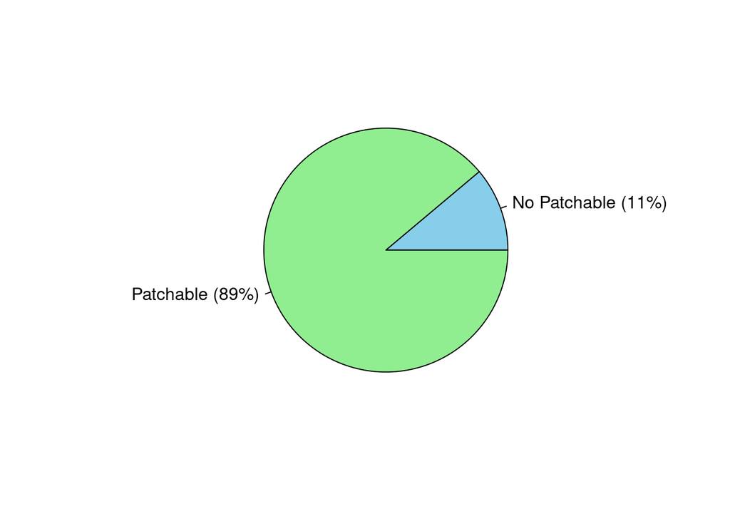

### Histograma

A continuación miraremos la distribución del número de CVEs y bug tracks. La primera gráfica que mostramos es el histograma del número de CVEs y Bugtraqs. Como vemos en la gráfica a continuación, la mayoría de vulnerabilidades tienen entre 0 y 20 CVEs/Bugtraqs:

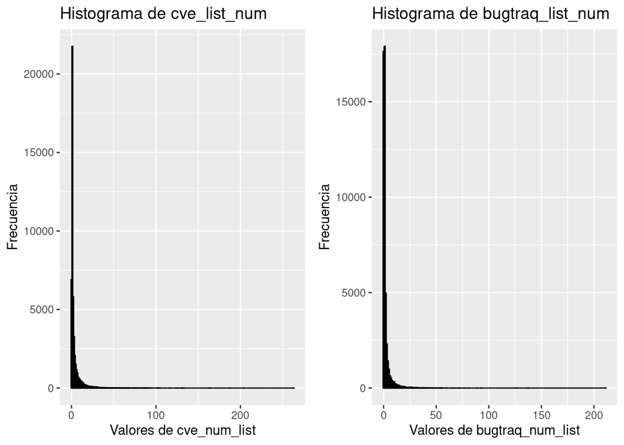

### Por categorias

La siguiente gráfica que mostraremos será en número de CVEs y Bugtraqs por categoría. Como muestran las gráficas siguientes, las 2 categorías donde existen más CVEs y Bugtraqs son:

- Local: Según Qualis, esta categoría está definida como: “This category consists of QIDs that detect vulnerabilities or gather information about vulnerabilities that can be exploited after getting local access to a box or vulnerabilities that need authenticated credentials to be detected.”
- SUSE: Según Qualis, esta categoría está definida como: “This is a platform-specific category for all vulnerabilities and informational checks that belong to SUSE Linux.”

Después de estas 2, las 2 siguientes son “OEL” (Oracle Enterprise Linux)y Ubuntu.

Por lo que se puede ver, 3 de las 4 vulnerabilidades con más CVEs y Bugtraqs corresponden a Sistemas Operativos Linux.

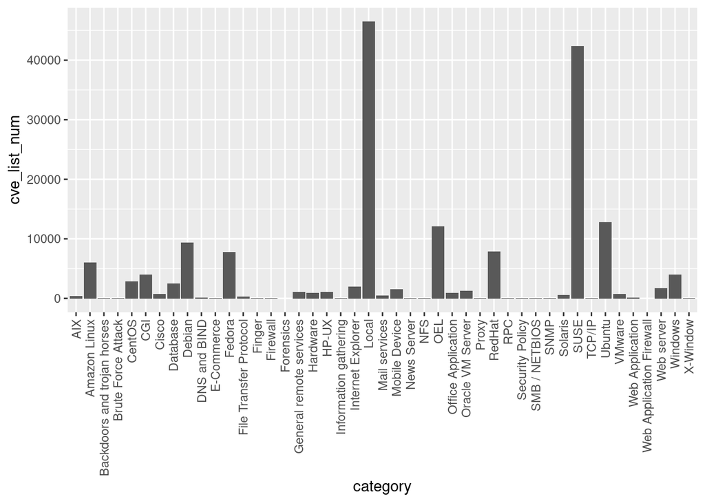

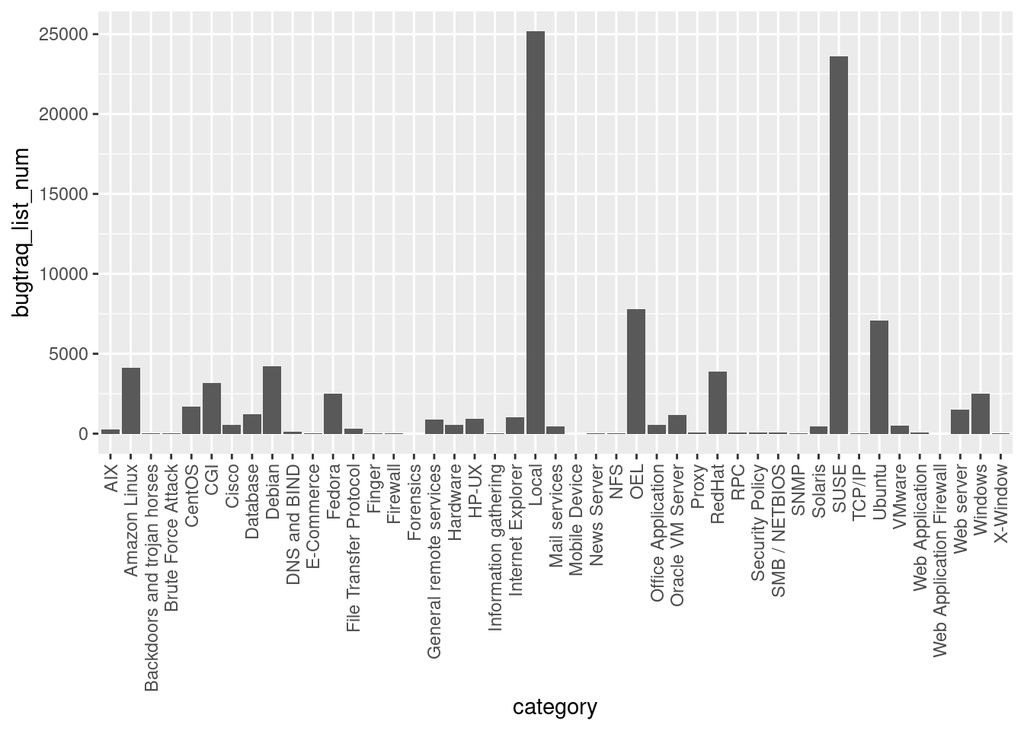

### Por severity

Si miramos el número de CVEs y Bugtraqs por severity, vemos que la mayoría son para severities 3 (Serious) y 4 (Critical):

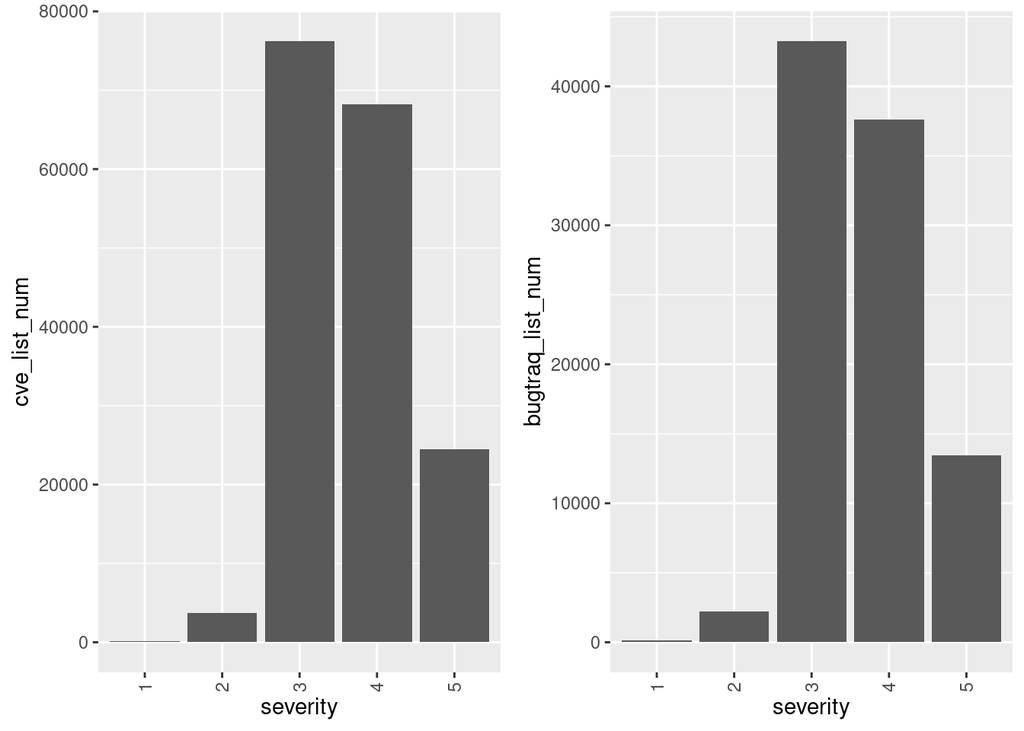

### Por published

En función del año de publicación de la vulnerabilidad, vemos que entre los años 2015 y 2019 son los años cuando más vulnerabilidades aparecieron:

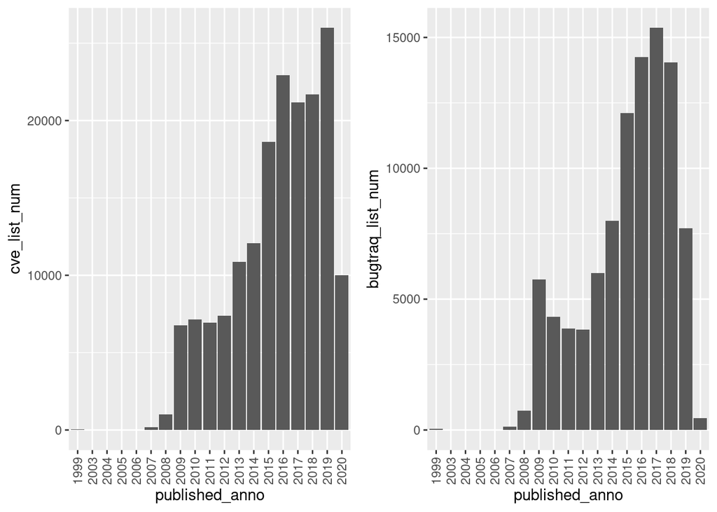